# 2026 SISBID Unsupervised Learning Comprehensive Lab

Genevera I. Allen & Yufeng Liu

# 1 Data description

This lab uses TCGA BRCA RNA-sequencing and clinical data.

## 1.1 Gene expression data: `gdat`

- `gdat` contains gene expression measurements for 445 patients and 353 genes.
- The retained genes are somatic-mutation-associated genes from COSMIC.
- The expression data are Level III TCGA BRCA RNA-sequencing data.
- The data have already been preprocessed:
  - reads normalized by RPKM;
  - overdispersion corrected by a log-transformation, `log(1 + data)`;
  - short gene names are provided as column names.

## 1.2 Clinical data: `cdat`

# 2 Lab goals

This is a comprehensive exploratory data analysis lab. Your goal is not to run every possible method, but to use multiple unsupervised-learning and statistical tools to develop a coherent understanding of the data.

For each method you use, think about:

1. What structure is the method designed to reveal?
2. What preprocessing choices does the method require?
3. How stable are the results?
4. How do the results relate to the clinical variables?
5. What biological or statistical conclusion is supported by the evidence?

# 3 Problems

## 3.1 Problem 1: Dimension reduction

1a. Apply several dimension-reduction methods to this dataset. At minimum, compare PCA and MDS. If time permits, also explore UMAP and t-SNE.

1b. Relate the dimension-reduction results to the clinical data. Is any clinical information reflected in the lower-dimensional spaces?

1c. Overall, which dimension-reduction method do you recommend for this dataset, and why?

## 3.2 Problem 2: Clustering

2a. Apply several clustering algorithms, such as K-means, hierarchical clustering, spectral clustering, or biclustering. Explore different values of `K`, distance metrics, or linkage functions where appropriate.

2b. Relate the clustering results to the clinical data. Can any clustering method recover clinical information such as PAM50 subtype?

2c. Optional: assess the stability or validation of one clustering result.

2d. Overall, which clustering method or methods do you recommend for this dataset, and why?

## 3.3 Problem 3: Multiple comparisons

3a. Identify genes associated with ER status, PR status, HER2 status, and metastasis status.

3b. Compare different multiple-comparisons procedures, such as Bonferroni, Holm, BH/FDR, and BY.

3c. Compare the gene lists identified under different procedures and clinical responses. Which approach is most appropriate for this exploratory analysis, and why?

## 3.4 Problem 4: Graphical models

4a. Use graphical models to explore relationships among genes.

4b. Are any well-connected genes related to patterns found in the dimension-reduction, clustering, or testing analyses?

4c. How sensitive are the estimated networks to the tuning parameter or method?

## 3.5 Problem 5: Visualization

5a. Visualize this dataset using multiple approaches.

5b. Prepare the best visual summary of this dataset for a short presentation.

## 3.6 Problem 6: Exploratory data analysis summary

6a. What is the most interesting finding from your analysis?

6b. Is this finding consistent and stable across methods?

6c. Prepare a visual summary that best illustrates your most interesting finding.

# 4 Starter R code

The code below is designed to help you begin the lab. It is intentionally incomplete: you should modify, extend, and interpret the code to answer the questions above.

## 4.1 Setup

```r
knitr::opts_chunk$set(
  echo = TRUE,
  message = FALSE,
  warning = FALSE,
  fig.width = 7,
  fig.height = 5
)

set.seed(2026)

pkg_available <- function(pkg) {
  requireNamespace(pkg, quietly = TRUE)
}

load_pkg <- function(pkg) {
  if (pkg_available(pkg)) {
    suppressPackageStartupMessages(library(pkg, character.only = TRUE))
    TRUE
  } else {
    message("Package '", pkg, "' is not installed; skipping code that requires it.")
    FALSE
  }
}

load_pkg("ggplot2")
```

```
## [1] TRUE
```

```r
load_pkg("GGally")
```

```
## [1] TRUE
```

```r
load_pkg("igraph")
```

```
## [1] TRUE
```

```r
load_pkg("umap")
```

```
## [1] TRUE
```

```r
load_pkg("Rtsne")
```

```
## [1] TRUE
```

## 4.2 Load and inspect data

```r
load("UnsupL_SISBID_2026.Rdata")

# Basic checks
stopifnot(exists("gdat"), exists("cdat"))
gdat <- as.matrix(gdat)
cdat <- as.data.frame(cdat)

# Add patient IDs if needed
if (is.null(rownames(gdat))) {
  rownames(gdat) <- paste0("Patient_", seq_len(nrow(gdat)))
}
if (is.null(rownames(cdat))) {
  rownames(cdat) <- rownames(gdat)
}

# Remove genes with zero variance.
# For this already log-transformed expression dataset, we keep the raw matrix
# for clustering/testing/network starter code. For dimension reduction, we
# center each gene but do not scale by the standard deviation.
#
# The one exception to the no-scaling rule is the bicluster heatmap below,
# where we scale the whole matrix only for visualization so gene-wise patterns
# are easier to see.
gene_sd <- apply(gdat, 2, sd, na.rm = TRUE)
gdat <- gdat[, gene_sd > 0, drop = FALSE]

# Raw analysis matrix used for clustering/testing/network starter code.
X <- gdat

# Centered-but-not-scaled matrix used for dimension reduction.
X_dr_centered <- scale(gdat, center = TRUE, scale = FALSE)

# Quick dimensions.
dim(gdat)
```

```
## [1] 445 353
```

```r
dim(cdat)
```

```
## [1] 445   6
```

```r
head(cdat)
```

```
##                 Subtype ER-Status PR-Status HER2-Status Node Metastasis
## TCGA-A1-A0SD  Luminal A  Positive  Positive    Negative    0          0
## TCGA-A1-A0SE  Luminal A  Positive  Positive    Negative    0          0
## TCGA-A1-A0SH  Luminal A  Negative  Positive    Negative    0          0
## TCGA-A1-A0SJ  Luminal A  Positive  Positive    Negative    1          0
## TCGA-A1-A0SK Basal-like  Negative  Negative    Negative    0          0
## TCGA-A1-A0SM  Luminal B  Positive  Negative    Positive    0          0
```

## 4.3 Explore clinical variables

```r
clinical_vars <- c("Subtype", "ER", "PR", "HER2", "Node", "Metastasis")
clinical_vars <- intersect(clinical_vars, colnames(cdat))

for (v in clinical_vars) {
  cat("\n", v, "\n", sep = "")
  print(table(cdat[[v]], useNA = "ifany"))
}
```

```
##
## Subtype
##
##    Basal-like HER2-enriched     Luminal A     Luminal B   Normal-like
##            79            53           200           106             7
##
## Node
##
##    0    1    2    3 <NA>
##  221  146   54   23    1
##
## Metastasis
##
##    0    1 <NA>
##  427   11    7
```

```r
# Example cross-tabulation.
if (all(c("ER", "PR") %in% colnames(cdat))) {
  table(ER = cdat$ER, PR = cdat$PR, useNA = "ifany")
}
```

## 4.4 Helper functions

```r
label_colors <- function(labels) {
  labels <- factor(labels)
  pal <- grDevices::hcl.colors(nlevels(labels), palette = "Dark 3")
  out <- pal[as.integer(labels)]
  names(out) <- as.character(labels)
  out
}

plot_embedding <- function(df, x, y, color_var, label_var = NULL, title = NULL) {
  if (!pkg_available("ggplot2")) {
    plot(df[[x]], df[[y]], pch = 16, col = label_colors(df[[color_var]]),
         xlab = x, ylab = y, main = title)
    legend("topright", legend = levels(factor(df[[color_var]])),
           col = unique(label_colors(df[[color_var]])), pch = 16, cex = 0.8)
    return(invisible(NULL))
  }

  p <- ggplot(df, aes(x = .data[[x]], y = .data[[y]], color = .data[[color_var]])) +
    geom_point(size = 2, alpha = 0.85) +
    labs(title = title, x = x, y = y, color = color_var) +
    theme_minimal()

  if (!is.null(label_var)) {
    p <- p + geom_text(aes(label = .data[[label_var]]), size = 2.5, show.legend = FALSE)
  }

  p
}

count_edges <- function(adj) {
  adj <- as.matrix(adj)
  adj[lower.tri(adj, diag = TRUE)] <- 0
  sum(adj != 0, na.rm = TRUE)
}

safe_ttest_p <- function(x, group) {
  keep <- !is.na(x) & !is.na(group)
  x <- x[keep]
  group <- droplevels(factor(group[keep]))
  if (nlevels(group) != 2) return(NA_real_)
  if (any(table(group) < 2)) return(NA_real_)
  tryCatch(t.test(x ~ group)$p.value, error = function(e) NA_real_)
}
```

# 5 Starter code for Problem 1: Dimension reduction

## 5.1 PCA

```r
# PCA on the centered-but-not-scaled expression matrix.
# This is equivalent to prcomp(gdat, center = TRUE, scale. = FALSE), but using
# X_dr_centered makes the preprocessing step explicit for students.
pca_fit <- prcomp(X_dr_centered, center = FALSE, scale. = FALSE)

pca_var <- pca_fit$sdev^2
pca_prop <- pca_var / sum(pca_var)

pca_var_df <- data.frame(
  PC = seq_along(pca_prop),
  PercentVariance = 100 * pca_prop,
  CumulativeVariance = 100 * cumsum(pca_prop)
)

head(pca_var_df, 10)
```

```
##    PC PercentVariance CumulativeVariance
## 1   1       15.246613           15.24661
## 2   2       12.158441           27.40505
## 3   3        6.920932           34.32599
## 4   4        5.383428           39.70941
## 5   5        4.766763           44.47618
## 6   6        3.776380           48.25256
## 7   7        2.624594           50.87715
## 8   8        2.091619           52.96877
## 9   9        1.918793           54.88756
## 10 10        1.610195           56.49776
```

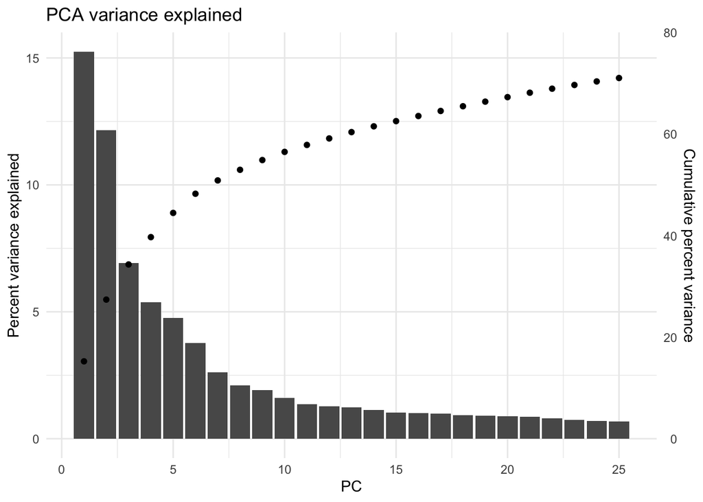

```r
ggplot(pca_var_df[1:25, ], aes(x = PC, y = PercentVariance)) +
  geom_col() +
  geom_point(aes(y = CumulativeVariance / 5)) +
  scale_y_continuous(
    name = "Percent variance explained",
    sec.axis = sec_axis(~ . * 5, name = "Cumulative percent variance")
  ) +
  labs(title = "PCA variance explained") +
  theme_minimal()
```

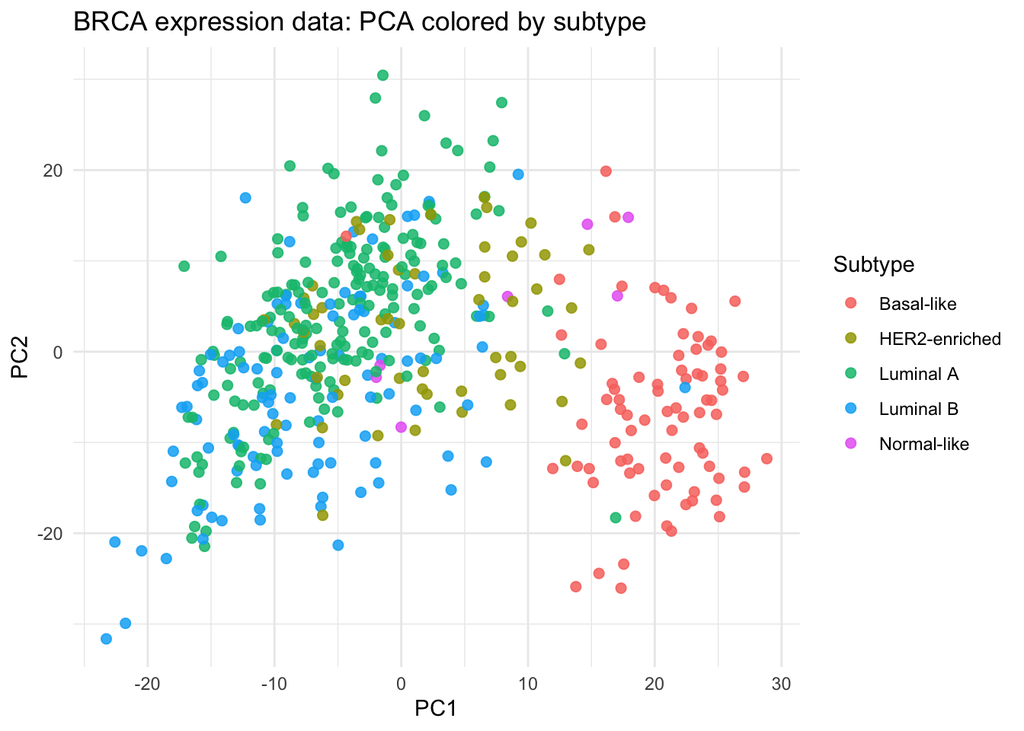

```r
pca_df <- data.frame(
  Patient = rownames(gdat),
  Subtype = cdat$Subtype,
  PC1 = pca_fit$x[, 1],
  PC2 = pca_fit$x[, 2],
  PC3 = pca_fit$x[, 3],
  PC4 = pca_fit$x[, 4]
)

plot_embedding(
  pca_df,
  x = "PC1",
  y = "PC2",
  color_var = "Subtype",
  title = "BRCA expression data: PCA colored by subtype"
)
```

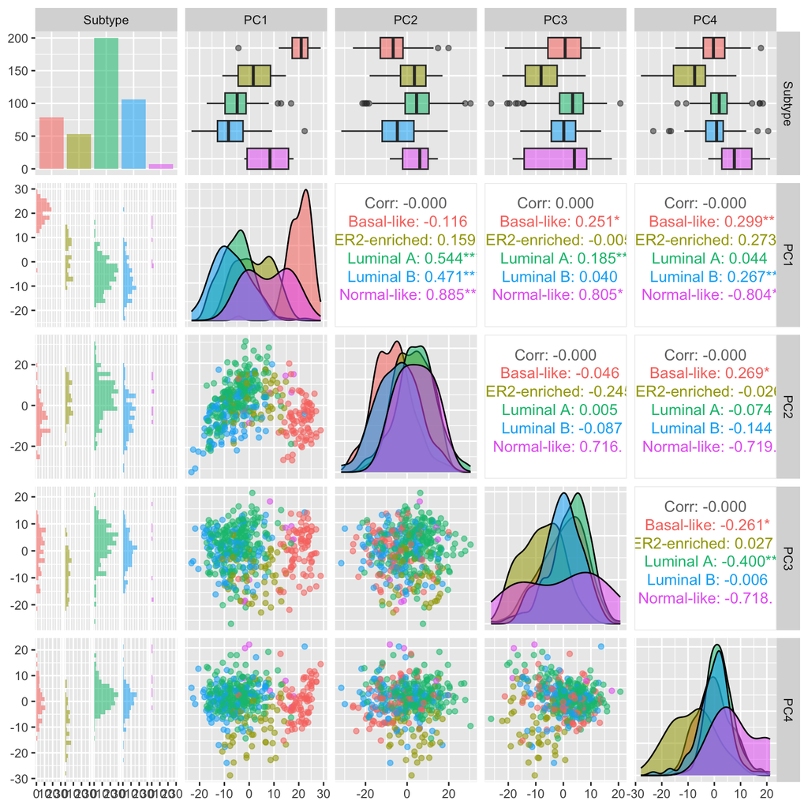

```r
# Inspect several PCs together.
# Explicitly print the ggpairs object so the plot appears when knitting.
if (load_pkg("GGally")) {
  p_pca_pairs <- GGally::ggpairs(
    pca_df[, c("Subtype", "PC1", "PC2", "PC3", "PC4")],
    mapping = ggplot2::aes(color = Subtype, alpha = 0.7)
  )
  print(p_pca_pairs)
} else {
  message("Install the GGally package to display the PCA pairs plot.")
}
```

## 5.2 MDS

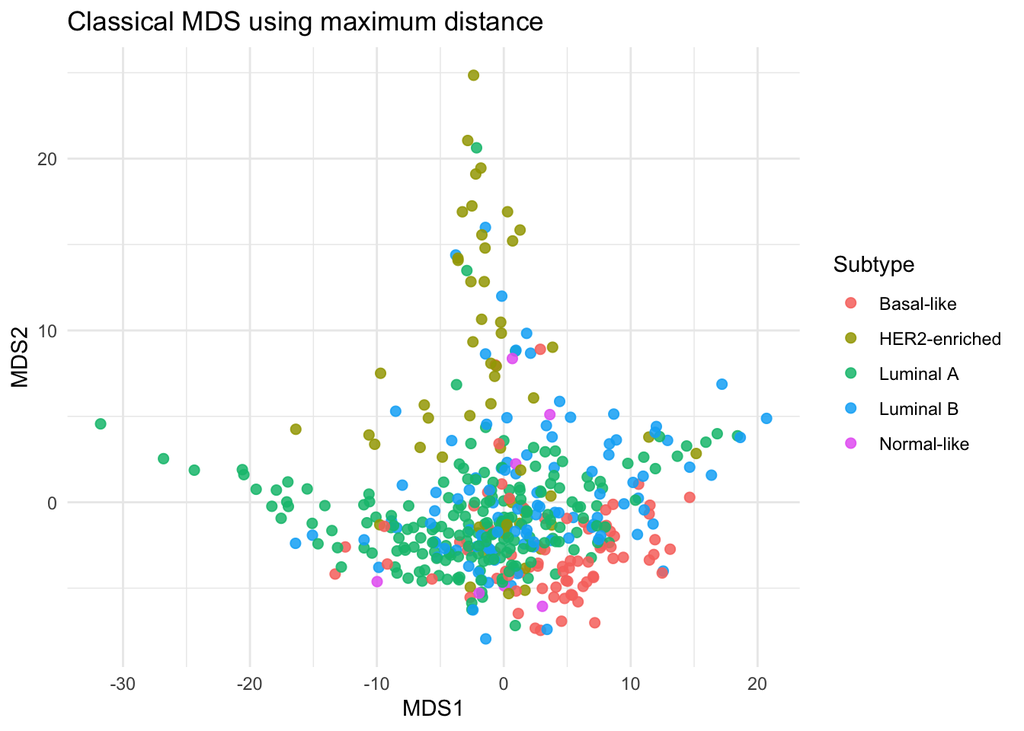

```r
# Classical MDS using centered-but-not-scaled data.
# We show two non-Euclidean distances so students can compare the geometry.
D_mds_max <- dist(X_dr_centered, method = "maximum")
mds_max <- cmdscale(D_mds_max, k = 2)

mds_max_df <- data.frame(
  Patient = rownames(gdat),
  Subtype = cdat$Subtype,
  MDS1 = mds_max[, 1],
  MDS2 = mds_max[, 2]
)

p_mds_max <- plot_embedding(
  mds_max_df,
  x = "MDS1",
  y = "MDS2",
  color_var = "Subtype",
  title = "Classical MDS using maximum distance"
)
print(p_mds_max)
```

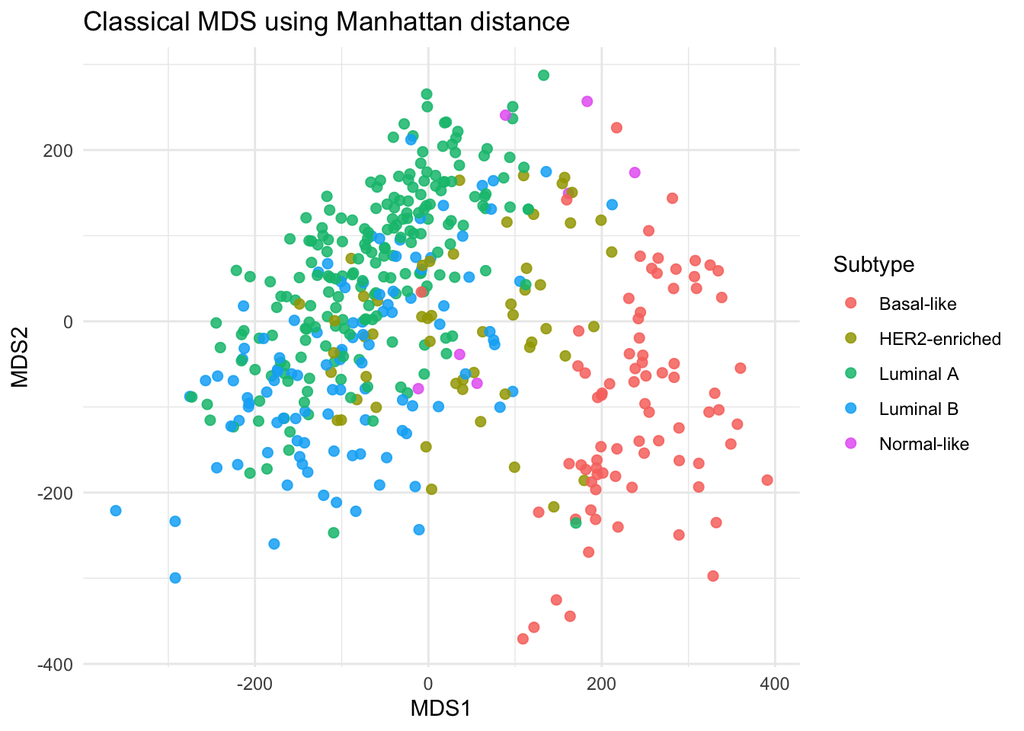

```r
# A second MDS view using Manhattan distance.
D_mds_man <- dist(X_dr_centered, method = "manhattan")
mds_man <- cmdscale(D_mds_man, k = 2)

mds_man_df <- data.frame(
  Patient = rownames(gdat),
  Subtype = cdat$Subtype,
  MDS1 = mds_man[, 1],
  MDS2 = mds_man[, 2]
)

p_mds_man <- plot_embedding(
  mds_man_df,
  x = "MDS1",
  y = "MDS2",
  color_var = "Subtype",
  title = "Classical MDS using Manhattan distance"
)
print(p_mds_man)
```

## 5.3 UMAP and t-SNE

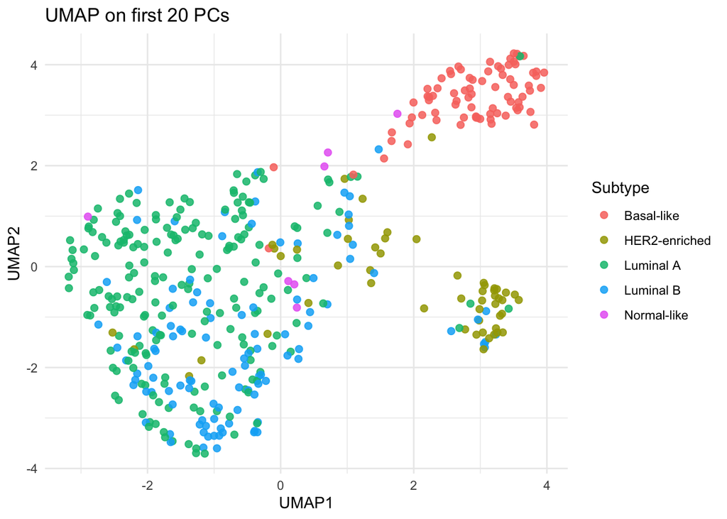

```r
# UMAP can be sensitive to tuning parameters.
# We use the first 20 PCs as input to reduce noise and speed up the algorithm.
X_dr <- pca_fit$x[, 1:20, drop = FALSE]

if (load_pkg("umap")) {
  set.seed(2026)
  umap_fit <- umap::umap(X_dr)
  umap_df <- data.frame(
    Subtype = cdat$Subtype,
    UMAP1 = umap_fit$layout[, 1],
    UMAP2 = umap_fit$layout[, 2]
  )
  print(plot_embedding(
    umap_df, "UMAP1", "UMAP2", "Subtype",
    title = "UMAP on first 20 PCs"
  ))
}
```

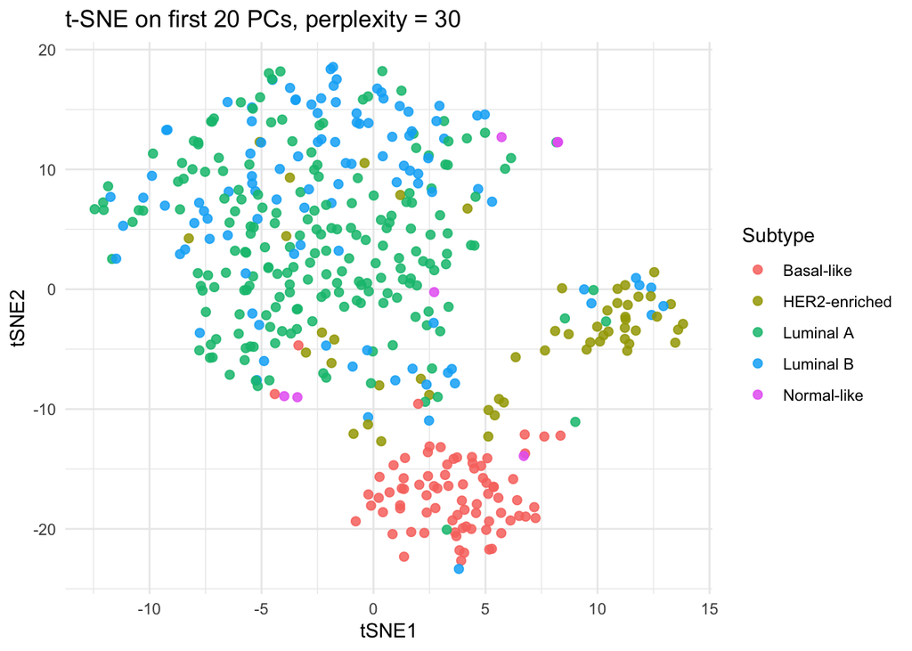

```r
# t-SNE is also sensitive to tuning parameters.
# Perplexity must be smaller than the number of samples.
if (load_pkg("Rtsne")) {
  set.seed(2026)
  tsne_perplexity <- min(30, floor((nrow(X_dr) - 1) / 3))
  tsne_fit <- Rtsne::Rtsne(
    X_dr,
    perplexity = tsne_perplexity,
    check_duplicates = FALSE,
    verbose = FALSE
  )
  tsne_df <- data.frame(
    Subtype = cdat$Subtype,
    tSNE1 = tsne_fit$Y[, 1],
    tSNE2 = tsne_fit$Y[, 2]
  )
  print(plot_embedding(
    tsne_df, "tSNE1", "tSNE2", "Subtype",
    title = paste("t-SNE on first 20 PCs, perplexity =", tsne_perplexity)
  ))
}
```

# 6 Starter code for Problem 2: Clustering

## 6.1 Heatmap and biclustering-style exploration

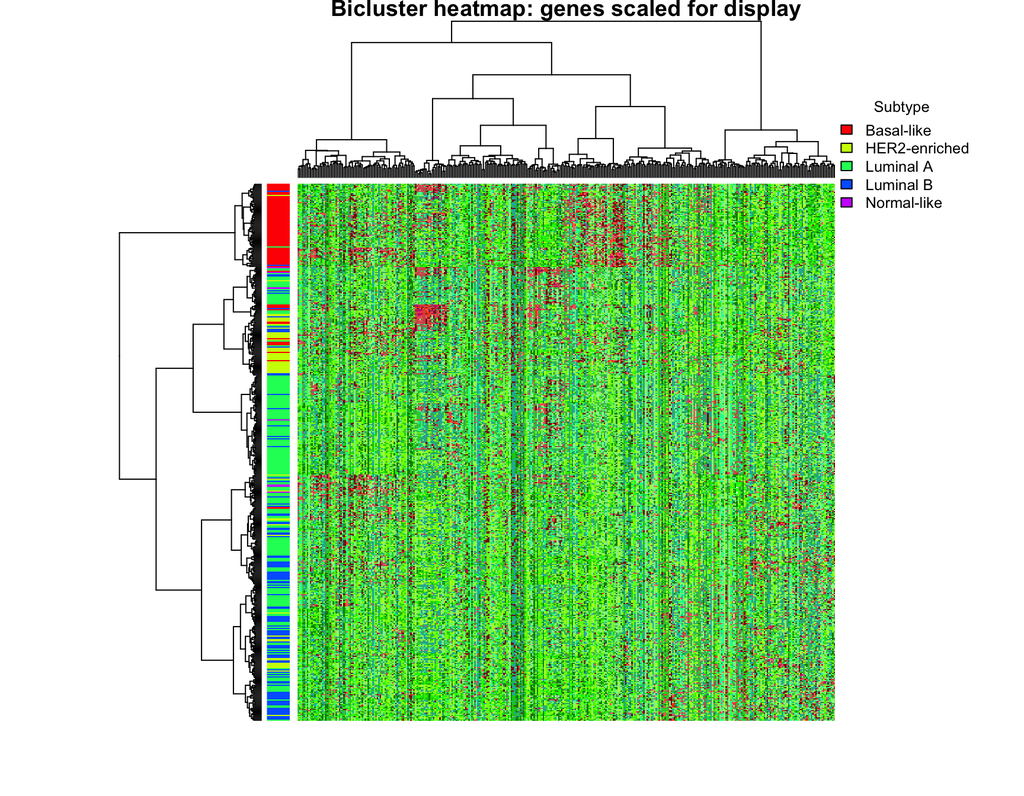

```r
# Bicluster-style heatmap.
# For this display only, scale the whole gene-expression matrix so genes with
# different expression ranges can be compared visually. Do not use this scaled
# matrix as the main analysis matrix elsewhere in the lab.
aa <- grep("grey", colors())
bb <- grep("green", colors())
cc <- grep("red", colors())
gcol2 <- colors()[c(aa[1:2], bb[1:25], cc[1:50])]

X_heat <- scale(gdat)

subtype <- factor(cdat$Subtype)
subtype_palette <- setNames(rainbow(nlevels(subtype)), levels(subtype))
subtype_colors <- subtype_palette[as.character(subtype)]

heatmap(
  X_heat,
  col = gcol2,
  scale = "none",
  hclustfun = function(x) hclust(x, method = "ward.D"),
  labRow = FALSE,
  labCol = FALSE,
  RowSideColors = subtype_colors,
  main = "Bicluster heatmap: genes scaled for display"
)

legend(
  "topright",
  legend = names(subtype_palette),
  fill = subtype_palette,
  title = "Subtype",
  cex = 0.8,
  bty = "n"
)
```

## 6.2 K-means clustering

```r
# Starter: run K-means for one value of K.
# Students: compare several K values and decide how to evaluate them.
set.seed(2026)
K <- 5
km_fit <- kmeans(X, centers = K, nstart = 50)

# Compare clusters to subtype as an external interpretation aid.
# Do not use subtype to fit the clusters.
table(KMeansCluster = km_fit$cluster, Subtype = cdat$Subtype)
```

```
##              Subtype
## KMeansCluster Basal-like HER2-enriched Luminal A Luminal B Normal-like
##             1          5             8        44        12           4
##             2          0             2        40        60           1
##             3         74             5         1         1           1
##             4          0            31         3         7           0
##             5          0             7       112        26           1
```

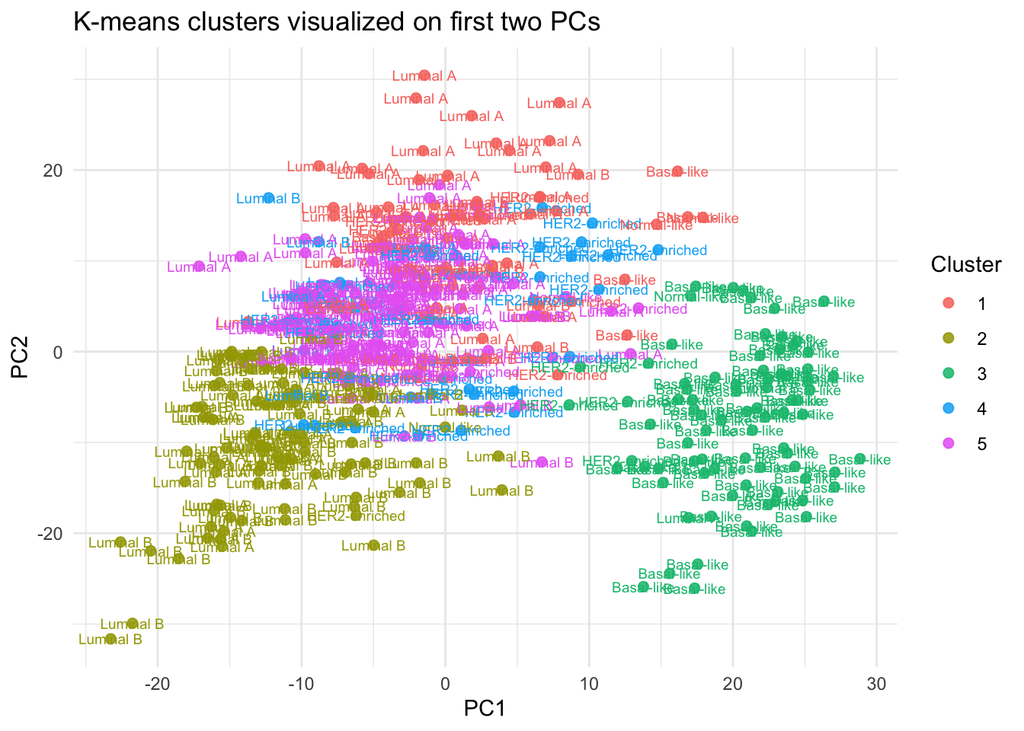

```r
km_pca_df <- data.frame(
  Subtype = cdat$Subtype,
  Cluster = factor(km_fit$cluster),
  PC1 = pca_fit$x[, 1],
  PC2 = pca_fit$x[, 2]
)

plot_embedding(
  km_pca_df,
  x = "PC1",
  y = "PC2",
  color_var = "Cluster",
  label_var = "Subtype",
  title = "K-means clusters visualized on first two PCs"
)
```

## 6.3 Hierarchical clustering

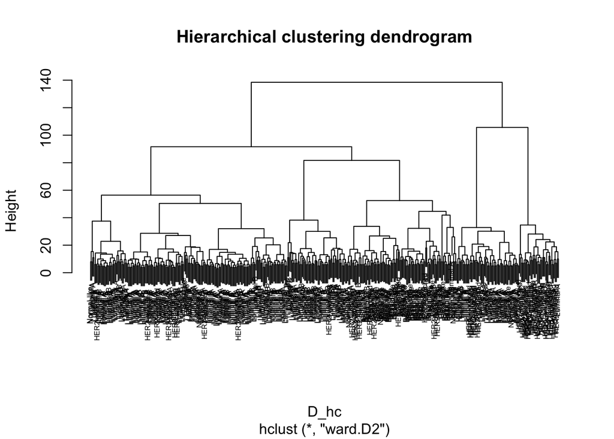

```r
# Starter: hierarchical clustering on the raw expression matrix.
# Students: try other distances and linkage methods.
D_hc <- dist(X, method = "maximum")
hc_fit <- hclust(D_hc, method = "ward.D2")

plot(hc_fit, labels = cdat$Subtype, cex = 0.5,
     main = "Hierarchical clustering dendrogram")
```

```r
hc_clusters <- cutree(hc_fit, k = 5)
table(HierCluster = hc_clusters, Subtype = cdat$Subtype)
```

```
##            Subtype
## HierCluster Basal-like HER2-enriched Luminal A Luminal B Normal-like
##           1          3             8       126        47           3
##           2          4             7        36        11           1
##           3          0             1        26        30           0
##           4         71            10         9        11           3
##           5          1            27         3         7           0
```

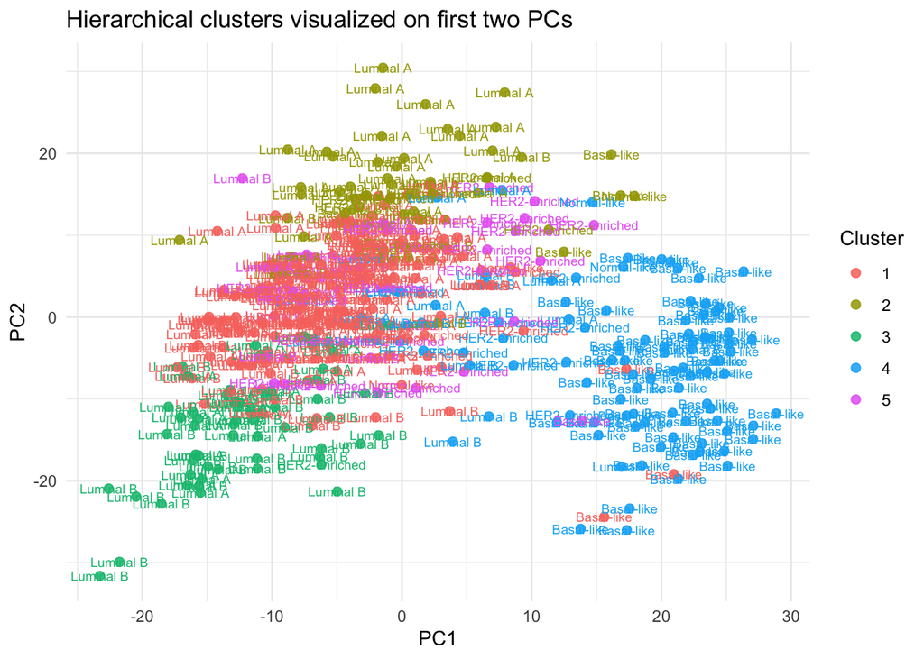

```r
# Visualize the flat hierarchical clustering assignments in PCA space.
# This mirrors the K-means PCA visualization above.
hc_pca_df <- data.frame(
  Subtype = cdat$Subtype,
  Cluster = factor(hc_clusters),
  PC1 = pca_fit$x[, 1],
  PC2 = pca_fit$x[, 2]
)

p_hc_pca <- plot_embedding(
  hc_pca_df,
  x = "PC1",
  y = "PC2",
  color_var = "Cluster",
  label_var = "Subtype",
  title = "Hierarchical clusters visualized on first two PCs"
)
print(p_hc_pca)
```

```r
# Starter template: compare alternative linkages or distances.
D_hc_alt <- dist(X, method = "manhattan")
hc_alt <- hclust(D_hc_alt, method = "average")
plot(hc_alt, labels = cdat$Subtype, cex = 0.5)
```

[output not shown]

# 7 Starter code for Problem 3: Multiple comparisons

## 7.1 Two-group testing helper

```r
two_group_gene_tests <- function(X, group) {
  group <- droplevels(factor(group))
  pvals <- apply(X, 2, safe_ttest_p, group = group)

  data.frame(
    Gene = colnames(X),
    PValue = pvals,
    Bonferroni = p.adjust(pvals, method = "bonferroni"),
    Holm = p.adjust(pvals, method = "holm"),
    BH = p.adjust(pvals, method = "BH"),
    BY = p.adjust(pvals, method = "BY"),
    row.names = NULL
  )
}

summarize_rejections <- function(test_df, alpha = 0.10) {
  data.frame(
    Method = c("Unadjusted", "Bonferroni", "Holm", "BH", "BY"),
    Rejections = c(
      sum(test_df$PValue < alpha, na.rm = TRUE),
      sum(test_df$Bonferroni < alpha, na.rm = TRUE),
      sum(test_df$Holm < alpha, na.rm = TRUE),
      sum(test_df$BH < alpha, na.rm = TRUE),
      sum(test_df$BY < alpha, na.rm = TRUE)
    )
  )
}
```

## 7.2 Example: ER status

```r
# Starter example for ER status.
# Students: repeat and adapt this for PR, HER2, and metastasis.
er_keep <- cdat$ER %in% c("Positive", "Negative")
X_er <- gdat[er_keep, , drop = FALSE]
er_group <- droplevels(factor(cdat$ER[er_keep]))

er_tests <- two_group_gene_tests(X_er, er_group)
er_tests <- er_tests[order(er_tests$PValue), ]

head(er_tests, 10)
```

```
##        Gene       PValue   Bonferroni         Holm           BH           BY
## 131   GATA3 6.134126e-40 2.165346e-37 2.165346e-37 2.165346e-37 1.395587e-36
## 155   IL6ST 9.374727e-39 3.309279e-36 3.299904e-36 1.654639e-36 1.066431e-35
## 220   MYST4 1.006078e-31 3.551456e-29 3.531334e-29 1.183819e-29 7.629829e-29
## 25     BCL2 2.251878e-28 7.949130e-26 7.881574e-26 1.987283e-26 1.280823e-25
## 124   FOXA1 4.135372e-28 1.459786e-25 1.443245e-25 2.919573e-26 1.881694e-25
## 240   NUMA1 6.276480e-26 2.215597e-23 2.184215e-23 3.692662e-24 2.379958e-23
## 41  CACNA1D 3.261112e-25 1.151173e-22 1.131606e-22 1.644532e-23 1.059917e-22
## 54    CCND1 2.912363e-24 1.028064e-21 1.007678e-21 1.285080e-22 8.282471e-22
## 282     RET 7.715962e-24 2.723734e-21 2.662007e-21 3.026372e-22 1.950527e-21
## 214     MYB 1.232211e-23 4.349706e-21 4.238807e-21 4.349706e-22 2.803429e-21
```

```r
summarize_rejections(er_tests, alpha = 0.10)
```

```
##       Method Rejections
## 1 Unadjusted        263
## 2 Bonferroni        168
## 3       Holm        177
## 4         BH        259
## 5         BY        217
```

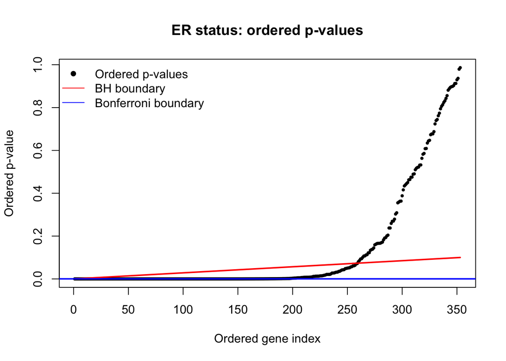

```r
alpha <- 0.10
m <- nrow(er_tests)
ordered_p <- sort(er_tests$PValue)

plot(
  ordered_p,
  pch = 16,
  cex = 0.6,
  xlab = "Ordered gene index",
  ylab = "Ordered p-value",
  main = "ER status: ordered p-values"
)
lines(seq_len(m), alpha * seq_len(m) / m, col = "red", lwd = 2)
abline(h = alpha / m, col = "blue", lwd = 2)
legend(
  "topleft",
  legend = c("Ordered p-values", "BH boundary", "Bonferroni boundary"),
  pch = c(16, NA, NA),
  lty = c(NA, 1, 1),
  col = c("black", "red", "blue"),
  bty = "n"
)
```

```r
# Starter template for another clinical response.
# Replace RESPONSE with PR, HER2, or Metastasis.
response <- cdat$PR
keep <- response %in% c("Positive", "Negative")

test_df <- two_group_gene_tests(
  X = gdat[keep, , drop = FALSE],
  group = response[keep]
)

test_df <- test_df[order(test_df$PValue), ]
head(test_df, 10)
summarize_rejections(test_df, alpha = 0.10)
```

[output not shown]

# 8 Starter code for Problem 4: Graphical models

## 8.1 Correlation network starter

```r
# Use a smaller set of genes for readable networks.
# Students: try different gene subsets, such as top variable genes or top genes from testing.
top_var_genes <- names(sort(apply(gdat, 2, var), decreasing = TRUE))
net_genes <- top_var_genes[1:40]
X_net <- X[, net_genes]

cor_mat <- cor(X_net)
cor_threshold <- 0.50
adj_cor <- abs(cor_mat) > cor_threshold
diag(adj_cor) <- FALSE

count_edges(adj_cor)
```

```
## [1] 25
```

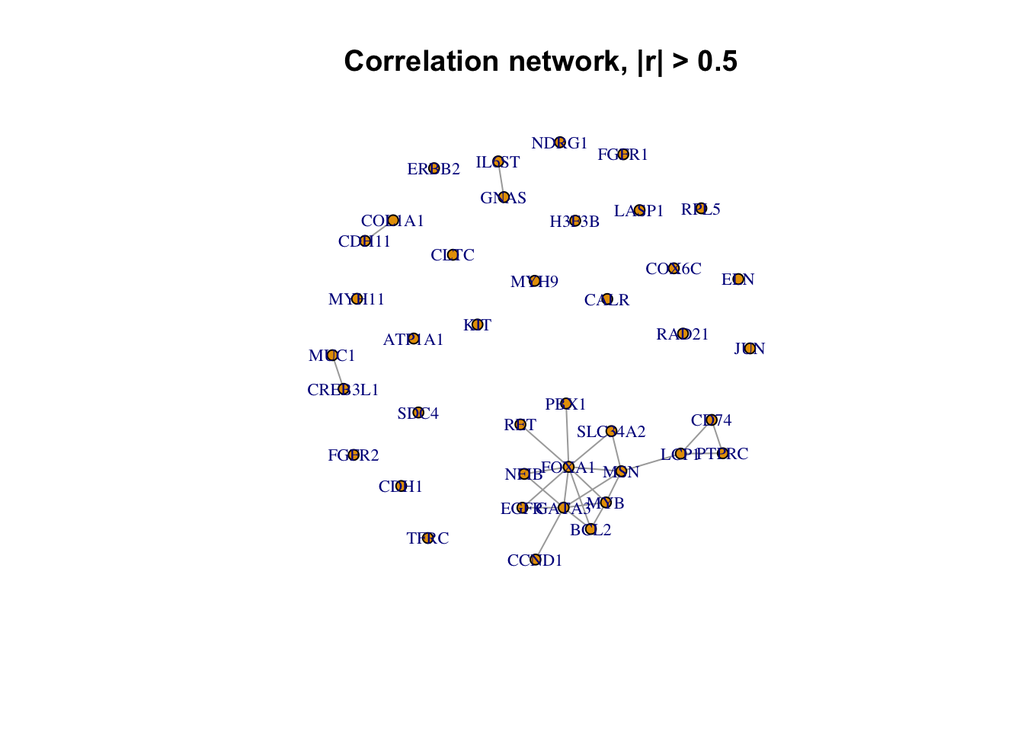

```r
if (load_pkg("igraph")) {
  g_cor <- graph_from_adjacency_matrix(adj_cor, mode = "undirected", diag = FALSE)
  plot(
    g_cor,
    vertex.label = colnames(X_net),
    vertex.size = 5,
    vertex.label.cex = 0.7,
    layout = layout_with_fr(g_cor),
    main = paste("Correlation network, |r| >", cor_threshold)
  )
}
```